# Reproducible Research: Peer Assessment 1

### Assignment Instructions

Clone the GitHub repository (https://github.com/rdpeng/RepData_PeerAssessment1) created for this assignment.

- NOTE: The GitHub repository contains the dataset for the assignment so there is no need to download the data separately. It also contains details regarding this course project.

Dataset: Activity monitoring data  
The variables included in this dataset are:

- **steps:** Number of steps taking in a 5-minute interval (missing values are coded as NA )
- **date:** The date on which the measurement was taken in YYYY-MM-DD format
- **interval:** Identifier for the 5-minute interval in which measurement was taken

### Loading and preprocessing the data

**Setup the working environment**

```r
        rm(list=ls(all=TRUE)) #clear the environment
        echo = TRUE #to include the code that used to generate the output
```

Read this dataset into a dataframe & inspect the data structure

```r
        unzip("activity.zip") #extract the csv file
        df = read.csv('activity.csv', header = T) #load data
        names(df)
```

```
## [1] "steps"    "date"     "interval"
```

```r
        str(df)
```

```
## 'data.frame':    17568 obs. of  3 variables:
##  $ steps   : int  NA NA NA NA NA NA NA NA NA NA ...
##  $ date    : Factor w/ 61 levels "2012-10-01","2012-10-02",..: 1 1 1 1 1 1 1 1 1 1 ...
##  $ interval: int  0 5 10 15 20 25 30 35 40 45 ...
```

```r
        head(df)
```

```
##   steps       date interval
## 1    NA 2012-10-01        0
## 2    NA 2012-10-01        5
## 3    NA 2012-10-01       10
## 4    NA 2012-10-01       15
## 5    NA 2012-10-01       20
## 6    NA 2012-10-01       25
```

### What is mean total number of steps taken per day?

Ignore missing values in dataset

1. Calculate the total number of steps taken per day

```r
        library(data.table)
        dt = data.table(df)
        dt_summary = dt[, list(total_steps = sum(steps, na.rm = T)), by = date]
        head(dt_summary)
```

```
##          date total_steps
## 1: 2012-10-01           0
## 2: 2012-10-02         126
## 3: 2012-10-03       11352
## 4: 2012-10-04       12116
## 5: 2012-10-05       13294
## 6: 2012-10-06       15420
```

```r
        tail(dt_summary)
```

```
##          date total_steps
## 1: 2012-11-25       11834
## 2: 2012-11-26       11162
## 3: 2012-11-27       13646
## 4: 2012-11-28       10183
## 5: 2012-11-29        7047
## 6: 2012-11-30           0
```

2. Make a histogram of the total number of steps taken each day

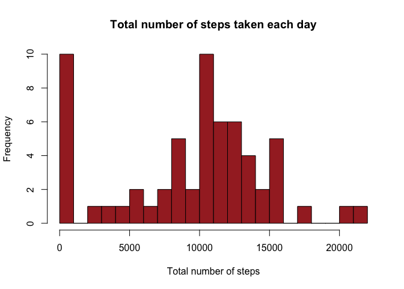

```r
        hist(dt_summary$total_steps, main="Total number of steps taken each day",
        xlab="Total number of steps", breaks = 30, col="brown")
```

3. Calculate and report the mean and median of the total number of steps taken per day

```r
        mean_stepsValue <- mean(dt_summary$total_steps)
        median_stepsValue <- median(dt_summary$total_steps)
        message(sprintf("Mean value of steps taken per day is %s", round(mean_stepsValue,0)))
```

```
## Mean value of steps taken per day is 9354
```

```r
        message(sprintf("Median value of steps taken per day is %s", median_stepsValue))
```

```
## Median value of steps taken per day is 10395
```

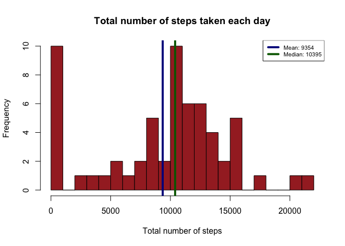

```r
        # Update the Histogram with Mean and Median lines and legends
        hist(dt_summary$total_steps, main="Total number of steps taken each day",
        xlab="Total number of steps", breaks = 30, col="brown")

        abline(v=mean_stepsValue, lwd=4, col="dark blue")
        abline(v=median_stepsValue, lwd=4, col="dark green")

        legend("topright", lty=1, lwd=4, col=c("dark blue","dark green"), cex=.7,
               legend = c(paste("Mean:", round(mean_stepsValue,0)),
                          paste("Median:", median_stepsValue)))
```

### What is the average daily activity pattern?

- Make a time series plot (i.e. type = “l”) of the 5-minute interval (x-axis) and the average number of steps taken, averaged across all days (y-axis)

```r
        dt_summary_timeSeries = dt[, list(avg_steps = mean(steps, na.rm = T)), by = interval]
        head(dt_summary_timeSeries)
```

```
##    interval avg_steps
## 1:        0 1.7169811
## 2:        5 0.3396226
## 3:       10 0.1320755
## 4:       15 0.1509434
## 5:       20 0.0754717
## 6:       25 2.0943396
```

```r
        tail(dt_summary_timeSeries)
```

```
##    interval avg_steps
## 1:     2330 2.6037736
## 2:     2335 4.6981132
## 3:     2340 3.3018868
## 4:     2345 0.6415094
## 5:     2350 0.2264151
## 6:     2355 1.0754717
```

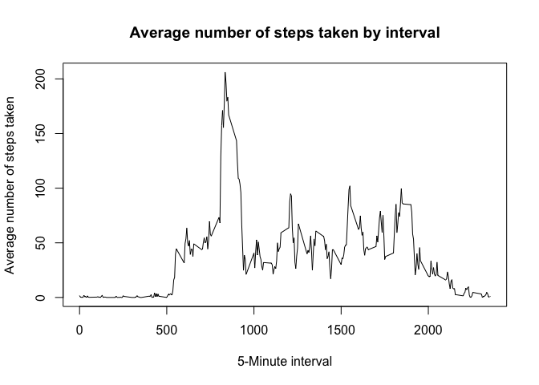

```r
        with(dt_summary_timeSeries, {
                plot(interval, avg_steps, type = "l",
                     main = "Average number of steps taken by interval",
                     xlab = "5-Minute interval",
                     ylab = "Average number of steps taken")
        })
```

- Which 5-minute interval, on average across all the days in the dataset, contains the maximum number of steps?

```r
        max_steps = dt_summary_timeSeries[which.max(avg_steps),]
        message(sprintf("There are maximum of %s average steps taken on %sth Interval", round(max_steps$avg_steps,0), max_steps$interval))
```

```
## There are maximum of 206 average steps taken on 835th Interval
```